# Understanding the Covariance Matrix

## Generate a dataset (2 features/variables) with variances == 1 & means == 0

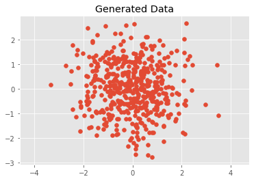

```python
import numpy as np
import matplotlib.pyplot as plt
%matplotlib inline

plt.style.use('ggplot')
# Normal distributed x and y vector with mean 0 and standard deviation 1
x = np.random.normal(0, 1, 500)
y = np.random.normal(0, 1, 500)
dataset = np.vstack((x, y)).T
plt.scatter(dataset[:, 0], dataset[:, 1])
plt.title('Generated Data')
plt.axis('equal');
```

**The covariance matrix of x & y would be:**

$C = \left( \begin{array}{ccc} \sigma_x^2 & 0 \\ 0 & \sigma_y^2 \end{array} \right)$

```python
dataset.T.shape
```

```
(2, 500)
```

```python
# Covariance
def cov(x, y):
    xbar, ybar = x.mean(), y.mean()
    return np.sum((x - xbar)*(y - ybar))/(len(x) - 1)

# Covariance matrix
def cov_mat(X):
    return np.array([[cov(X[:, 0], X[:, 0]), cov(X[:, 0], X[:, 1])], \
                     [cov(X[:, 1], X[:, 0]), cov(X[:, 1], X[:, 1])]])
```

```python
# Calculate covariance matrix
cov_mat(dataset) # (or with np.cov(dataset.T))
```

```
array([[ 1.13473045, -0.06389238],
       [-0.06389238,  1.06396783]])
```

## Perform linear transformation with data

### Scale the data with following matrix

$S = \left( \begin{array}{ccc} s_x & 0 \\ 0 & s_y \end{array} \right)$

```
array([[ 0.55601792, -0.15206386],
       [-0.15206386, 12.29946814]])
```

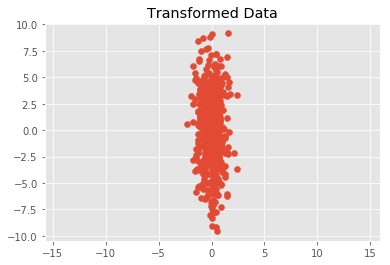

```python
# Scaling matrix
sx, sy = 0.7, 3.4
Scale = np.array([[sx, 0], [0, sy]])
# Apply scaling matrix to X
transformed_dataset = dataset.dot(Scale)

plt.scatter(transformed_dataset[:, 0], transformed_dataset[:, 1])
plt.title('Transformed Data')
plt.axis('equal')
# Calculate covariance matrix
cov_mat(transformed_dataset)
```

After performing the scaling transformation by multiplying x & y variables by $s_x$ & $s_y$ respectively. The covariance matrix $C$ of the transformed data would be:

$C = \left( \begin{array}{ccc} (s_x\sigma_x)^2 & 0 \\ 0 & (s_y\sigma_y)^2 \end{array} \right)$

### Rotate the scaled data with following matrix ($R$)

$R = \left( \begin{array}{ccc} cos(\theta) & -sin(\theta) \\ sin(\theta) & cos(\theta) \end{array} \right)$

where $θ$ is the rotation angle. The transformed data is then calculated by:

$Newdataset$ = $R*S*Dataset$

= $T*Dataset$

in which $T=RS$

```
array([[ 5.84268552, -5.84448346],
       [-5.84448346,  7.01280054]])
```

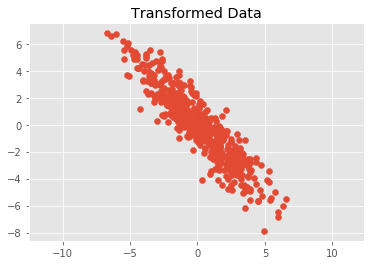

```python
# Rotation matrix
theta = 0.77*np.pi
c, s = np.cos(theta), np.sin(theta)
Rot = np.array([[c, -s], [s, c]])

# Transformation matrix
T = Scale.dot(Rot)

# Apply transformation matrix to newdataset
newdataset = dataset.dot(T)

plt.scatter(newdataset[:, 0], newdataset[:, 1])
plt.title('Transformed Data')
plt.axis('equal')
# Calculate covariance matrix
cov_mat(newdataset)
```

**Critical thinking: How to decompose covariance matrix $C$ into rotation matrix $R$ and scaling matrix $S$ ?**

**Ans: Use Eigen Decomposition of Covariance Matrix**

**Critical thinking: Why should we care about decomposition of covariance matrix $C$ ?**

**Ans: It gives us the direction in which data varies the most (principle components)**

## Eigen Decomposition

An eigenvector is a vector that remains unchanged when there is a linear transformation applied to it. The formula can be expressed as follows

$Av=\lambda v$

where $v$ is eigenvector and $\lambda$ is eigenvalue

However, the formula above is just a single pair of eigenvector and eigenvalue used to interpret for a single linear transformation.

For more complicated cases, which multiple linear transformations occur, we need several pairs of eigenvector and eigenvalue in order to express that linear transformations.

=> If we put all the eigenvectors into columns of matrix $V$ && all eigenvalues into diagonal entries of matrix $L$ that leaves everything 0 except for the diagonal entries, then we can generalize the formula above into matrix form as follows

$CV = VL\space$ (Diagonalization theorem)

$\iff C = VLV^{-1}\tag{1}$

where $C$ is the covariance matrix and $V$ & $C$ are the eigenvector matrix and eigenvalue diagonal matrix of matrix $C$ respectively

Since eigenvectors represent the direction of the largest variance of the data. While the eigenvalues illustrate the magnitude of this variance in the corresponding direction => $V$ can represent the rotation matrix && $\sqrt{L}$ stands for scaling matrix

$\Rightarrow C = RSSR^{-1}$

Knowing that

- Rotation matrix $R$ is orthogonal matrix $\rightarrow RR^{-1} = I$ & $R^{-1} = R^{T}$
- Scale matrix $S$ is diagonal symmetric matrix $\rightarrow S=S^{T}$

$\rightarrow C = RSS^{T}R^{T} = RS(RS)^{T} = TT^{T}\tag{2}$

$(1), (2) \Rightarrow T=V\sqrt{L}$

### Draw the basis vectors of transformation matrix based on eigenvectors and eigenvalues we obtained

```
[-0.74148715 -0.67096706]
[ 0.67096706 -0.74148715]
```

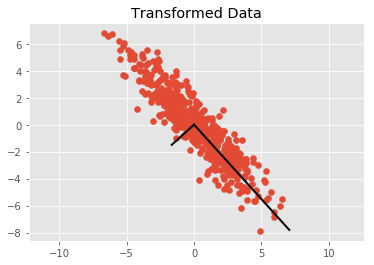

```python
C = cov_mat(newdataset)
eVal, eVector = np.linalg.eig(C) #eigenvectors lie in columns of matrix eVector

plt.scatter(newdataset[:, 0], newdataset[:, 1])
for e, v in zip(eVal, eVector.T): # eVector.T to transpose each eigenvector into row in order to iterate for each loop
    print(v)
    plt.plot([0, 3*np.sqrt(e)*v[0]], [0, 3*np.sqrt(e)*v[1]], 'k-', lw=2)
plt.title('Transformed Data')
plt.axis('equal');
```

### Convert back to original data using eigenvectors & eigenvalues to find the inverted transformation matrix

```
array([[1.00000000e+00, 3.80902168e-16],
       [3.80902168e-16, 1.00000000e+00]])
```

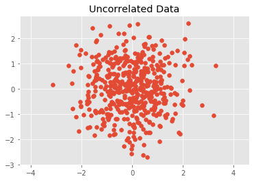

```python
C = cov_mat(newdataset)
eVal, eVector = np.linalg.eig(C) #eigenvectors lie in columns of matrix eVector
# Calculate transformation matrix from eigen decomposition
R, S = eVector, np.diag(np.sqrt(eVal))
T = R.dot(S).T
# Transform data with inverse transformation matrix T^-1
originalDataset = newdataset.dot(np.linalg.inv(T))

plt.scatter(originalDataset[:, 0], originalDataset[:, 1])
plt.title('Uncorrelated Data')
plt.axis('equal');

# Covariance matrix of the uncorrelated data
cov_mat(originalDataset)
```